# Modelling

Peter Tran

```r
library(survival)
library(survminer)
library(tidyverse)
```

This assumes we’ve already processed the data in `../data/process.Rmd`.

```r
ems_traffic <- read_rds("../../data/processed/ems_traffic.rds")
```

# Kaplan-Meier survival curves

Let’s start by seeing if there’s a difference in survival times between majority white and non majority white areas through the survival curves.

```r
s <- survfit(Surv(INCIDENT_RESPONSE_SECONDS_QY) ~ majority_white, data = ems_traffic)
s
```

```
## Call: survfit(formula = Surv(INCIDENT_RESPONSE_SECONDS_QY) ~ majority_white,
##     data = ems_traffic)
##
##    44 observations deleted due to missingness
##                           n events median 0.95LCL 0.95UCL
## majority_white=FALSE 293726 293726    491     490     492
## majority_white=TRUE  125105 125105    422     421     424
```

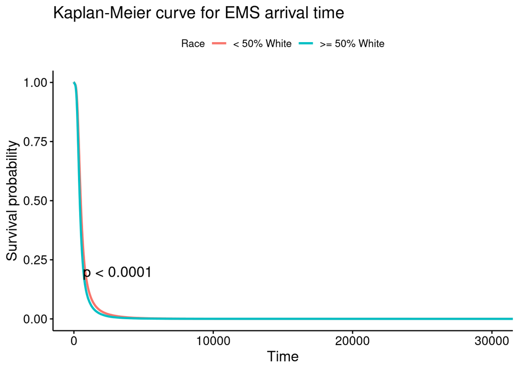

```r
ggsurvplot(s, pval = T, legend.labs = c("< 50% White", ">= 50% White"), legend.title = "Race", title = "Kaplan-Meier curve for EMS arrival time")
```

It definitely looks like there’s a difference, and the log-rank test confirms it. Additionally, looking at the median survival time, it looks like white patients can expect a 1 minute sooner response time. Let’s take a look at only response times that were less than an hour to see it better.

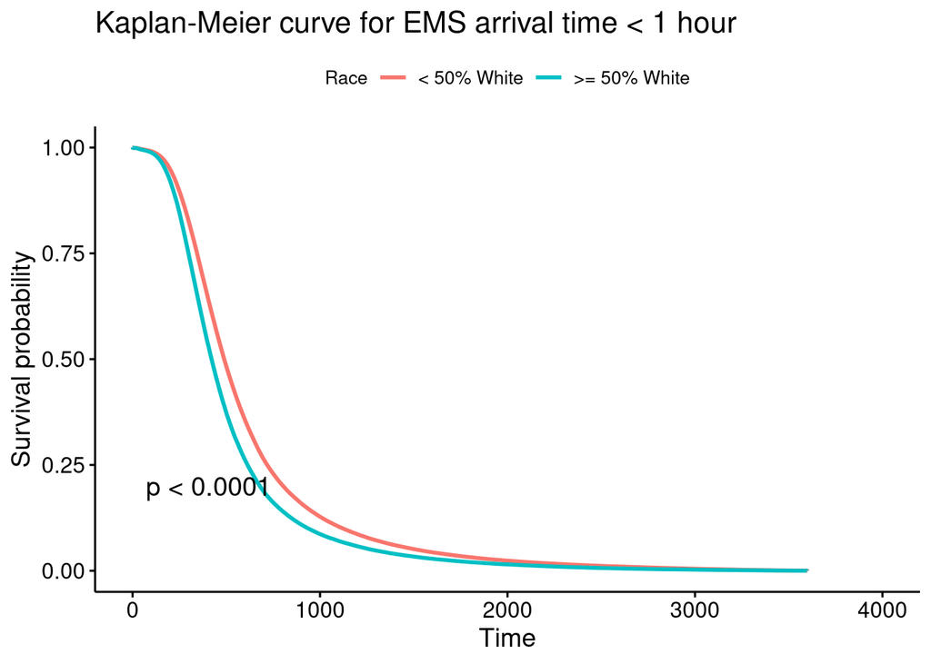

```r
survfit(Surv(INCIDENT_RESPONSE_SECONDS_QY) ~ majority_white, data = ems_traffic %>% filter(INCIDENT_RESPONSE_SECONDS_QY < 3600)) %>%
  ggsurvplot(pval = T, legend.labs = c("< 50% White", ">= 50% White"), legend.title = "Race", title = "Kaplan-Meier curve for EMS arrival time < 1 hour")
```

Yeah it is much more pronounced here. It looks like around the hour mark the difference disappears. Of course this could be confounded by a whole host of factors that the Kaplan-Meier curve doesn’t take into account. We’ll need to do a more sophisticated model to tease that.

# Cox proportional hazards model

```r
model <- coxph(Surv(INCIDENT_RESPONSE_SECONDS_QY) ~ majority_white + INITIAL_SEVERITY_LEVEL_CODE + HELD_INDICATOR + REOPEN_INDICATOR + SPECIAL_EVENT_INDICATOR + STANDBY_INDICATOR + TRANSFER_INDICATOR + traffic, data = ems_traffic)
model
```

```
## Call:
## coxph(formula = Surv(INCIDENT_RESPONSE_SECONDS_QY) ~ majority_white +
##     INITIAL_SEVERITY_LEVEL_CODE + HELD_INDICATOR + REOPEN_INDICATOR +
##     SPECIAL_EVENT_INDICATOR + STANDBY_INDICATOR + TRANSFER_INDICATOR +
##     traffic, data = ems_traffic)
##
##                                   coef  exp(coef)   se(coef)        z        p
## majority_whiteTRUE           2.484e-01  1.282e+00  3.475e-03   71.468  < 2e-16
## INITIAL_SEVERITY_LEVEL_CODE -2.186e-01  8.037e-01  9.714e-04 -225.013  < 2e-16
## HELD_INDICATORY             -1.426e+00  2.403e-01  6.837e-03 -208.555  < 2e-16
## REOPEN_INDICATORY           -4.775e-01  6.203e-01  2.288e-02  -20.868  < 2e-16
## SPECIAL_EVENT_INDICATORY    -1.671e+00  1.881e-01  3.789e-01   -4.411 1.03e-05
## STANDBY_INDICATORY          -1.213e+00  2.973e-01  5.140e-02  -23.601  < 2e-16
## TRANSFER_INDICATORY         -8.171e-01  4.417e-01  5.774e-01   -1.415    0.157
## traffic                     -2.807e-04  9.997e-01  1.527e-05  -18.382  < 2e-16
##
## Likelihood ratio test=128360  on 8 df, p=< 2.2e-16
## n= 418831, number of events= 418831
##    (44 observations deleted due to missingness)
```

According to our Cox model, if you live in a non-majority white zip code you can expect to have EMS arrive about 1.28 times longer than they would take in majority white zip codes. Granted most EMS arrival times are under 10 minutes in this dataset, therefore this amounts to a 1 or 2 minute longer wait, which is certainly not nothing.

We do need to check our model for the PH assumption though.

```r
cox.zph(model)
```

```
##                               chisq df       p
## majority_white              1392.83  1 < 2e-16
## INITIAL_SEVERITY_LEVEL_CODE  535.27  1 < 2e-16
## HELD_INDICATOR              2505.81  1 < 2e-16
## REOPEN_INDICATOR             451.13  1 < 2e-16
## SPECIAL_EVENT_INDICATOR       16.22  1 5.6e-05
## STANDBY_INDICATOR           1121.98  1 < 2e-16
## TRANSFER_INDICATOR             1.14  1    0.29
## traffic                       44.68  1 2.3e-11
## GLOBAL                      5511.37  8 < 2e-16
```

Looks like most of our variables fail to meet the assumption pretty spectacularly, but remember that we have an obscene amount of observations so of course we will find plenty of evidence to reject the null. Since most of our variables are categorical, we can use log-minus-log plots to check them. For `traffic`, we can plot the Schoenfeld residuals.

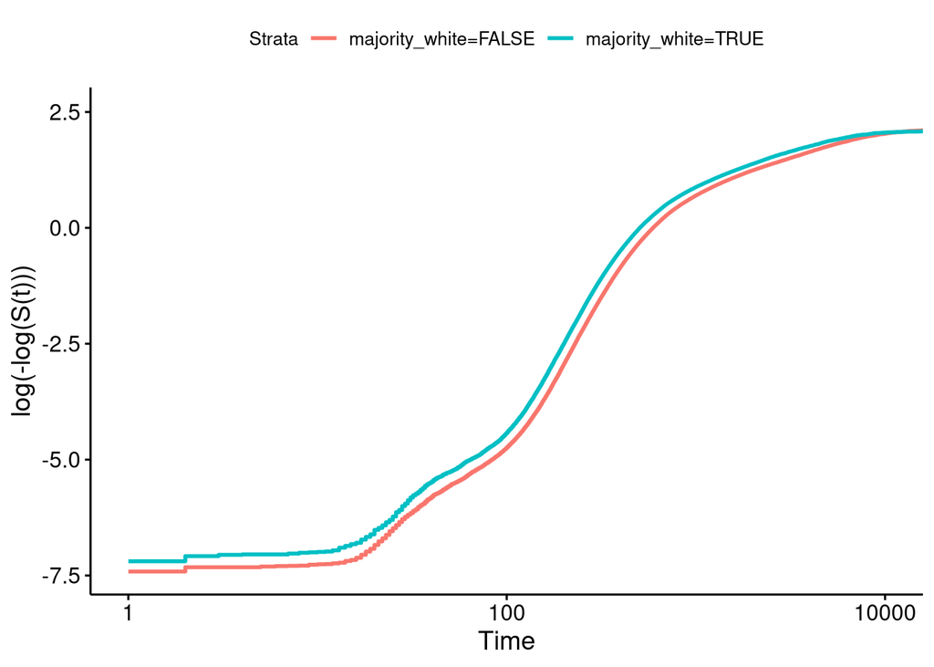

```r
survfit(Surv(INCIDENT_RESPONSE_SECONDS_QY) ~ majority_white, data = ems_traffic) %>%
  ggsurvplot(fun = "cloglog")
```

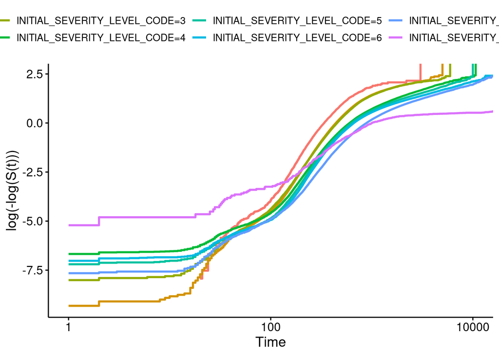

```r
survfit(Surv(INCIDENT_RESPONSE_SECONDS_QY) ~ INITIAL_SEVERITY_LEVEL_CODE, data = ems_traffic) %>%
  ggsurvplot(fun = "cloglog")
```

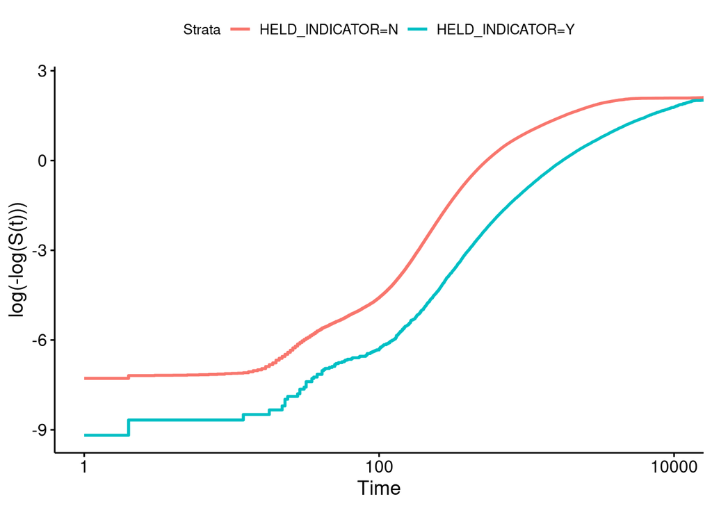

```r
survfit(Surv(INCIDENT_RESPONSE_SECONDS_QY) ~ HELD_INDICATOR, data = ems_traffic) %>%
  ggsurvplot(fun = "cloglog")
```

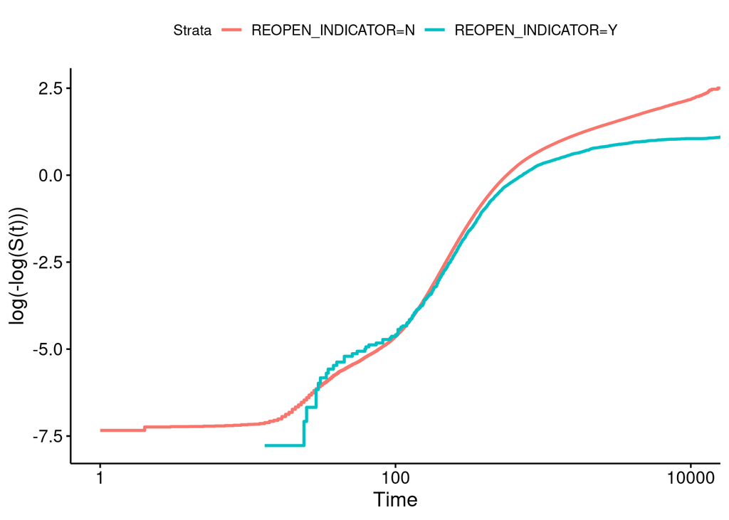

```r
survfit(Surv(INCIDENT_RESPONSE_SECONDS_QY) ~ REOPEN_INDICATOR, data = ems_traffic) %>%
  ggsurvplot(fun = "cloglog")
```

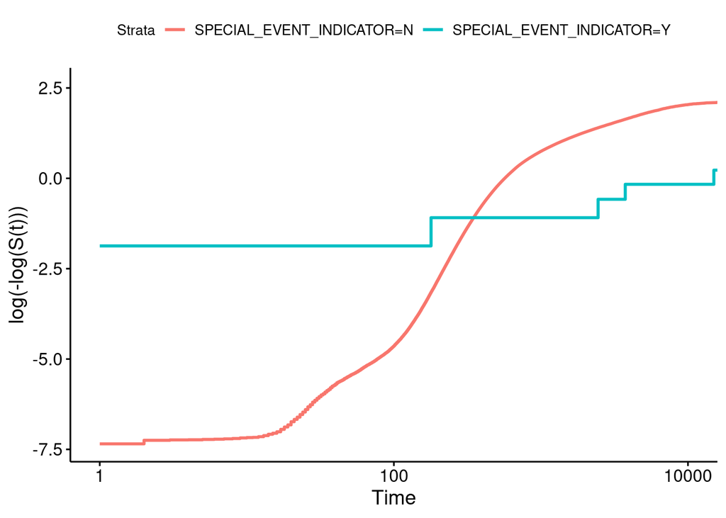

```r
survfit(Surv(INCIDENT_RESPONSE_SECONDS_QY) ~ SPECIAL_EVENT_INDICATOR, data = ems_traffic) %>%
  ggsurvplot(fun = "cloglog")
```

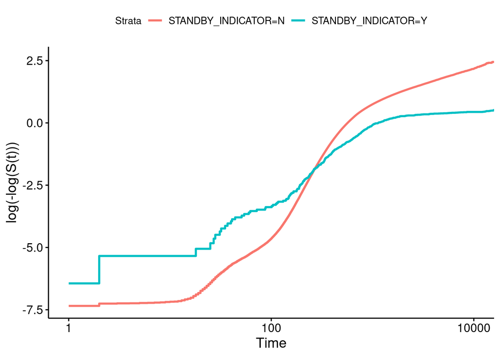

```r
survfit(Surv(INCIDENT_RESPONSE_SECONDS_QY) ~ STANDBY_INDICATOR, data = ems_traffic) %>%
  ggsurvplot(fun = "cloglog")
```

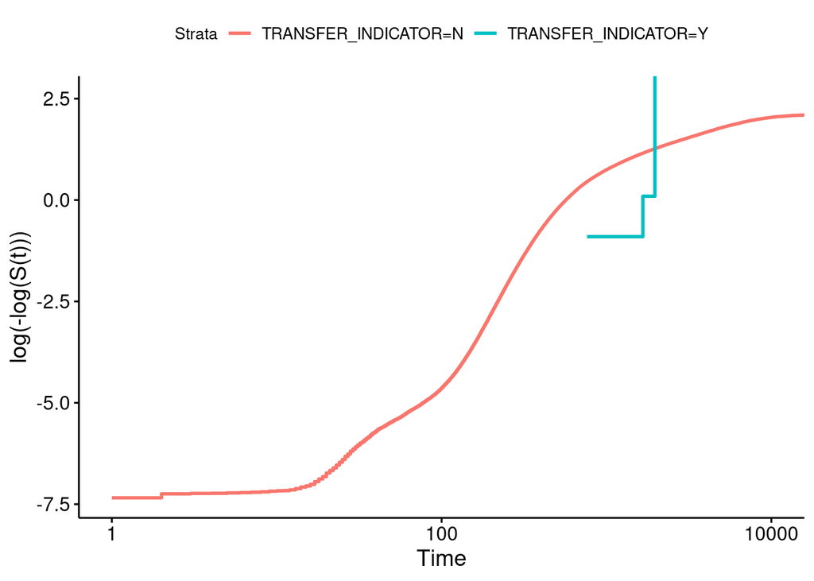

```r
survfit(Surv(INCIDENT_RESPONSE_SECONDS_QY) ~ TRANSFER_INDICATOR, data = ems_traffic) %>%
  ggsurvplot(fun = "cloglog")
```

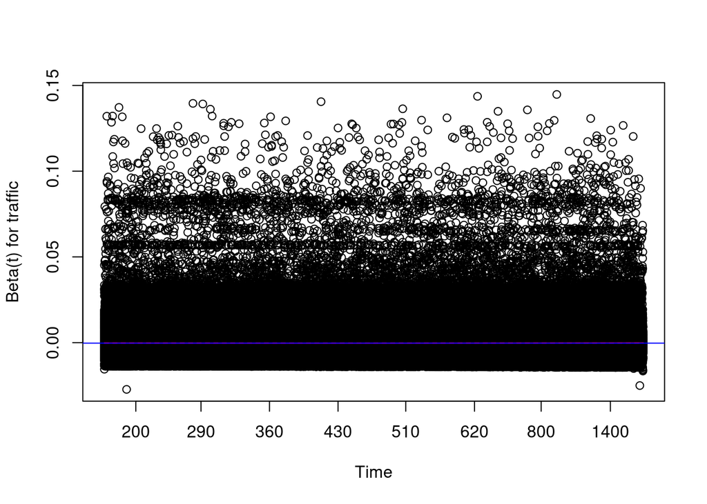

```r
plot(cox.zph(model), var = 8, col = "red")
abline(h = coef(model)[8], col = "blue")
```

It looks like the PH assumption is not met for most of our categorical variables. Since we aren’t actually interested in their effects, we just want to control for them, we can simply stratify our model on them.

You could argue that the assumption is not met for `majority_white` and `HELD_INDICATOR`, but it’s proportional for most of the time and doesn’t start to converge till near the end. I believe this is still useful as the vast majority of EMS arrival times are fairly fast and we are concerned about the disparities in that time frame in particular.

```r
model2 <- coxph(Surv(INCIDENT_RESPONSE_SECONDS_QY) ~ majority_white + HELD_INDICATOR + traffic + strata(INITIAL_SEVERITY_LEVEL_CODE, REOPEN_INDICATOR, SPECIAL_EVENT_INDICATOR, STANDBY_INDICATOR, TRANSFER_INDICATOR), data = ems_traffic)
model2
```

```
## Call:
## coxph(formula = Surv(INCIDENT_RESPONSE_SECONDS_QY) ~ majority_white +
##     HELD_INDICATOR + traffic + strata(INITIAL_SEVERITY_LEVEL_CODE,
##     REOPEN_INDICATOR, SPECIAL_EVENT_INDICATOR, STANDBY_INDICATOR,
##     TRANSFER_INDICATOR), data = ems_traffic)
##
##                          coef  exp(coef)   se(coef)       z      p
## majority_whiteTRUE  2.541e-01  1.289e+00  3.478e-03   73.05 <2e-16
## HELD_INDICATORY    -1.460e+00  2.323e-01  7.039e-03 -207.39 <2e-16
## traffic            -2.831e-04  9.997e-01  1.528e-05  -18.52 <2e-16
##
## Likelihood ratio test=64116  on 3 df, p=< 2.2e-16
## n= 418831, number of events= 418831
##    (44 observations deleted due to missingness)
```

This increases our HR for `majority_white` to 1.29.

# Predictions based on white proportion for mapping

```r
library(sf)
library(tigris)
options(tigris_use_cache = T)
```

Now that we know what the differential is between majority white and non-majority white zip codes and their EMS arrival times, we also want to create some visualizations of this. One in particular is to map the “survival” times of each zip code based on their white proportion. To do this, we’ll fit another Cox model but this time using the proportion of white population as a continuous variable.

Once we have that, we can get Cox-adjusted KM survival estimates.

```r
model3 <- coxph(Surv(INCIDENT_RESPONSE_SECONDS_QY) ~ white_proportion + HELD_INDICATOR + traffic + strata(INITIAL_SEVERITY_LEVEL_CODE, REOPEN_INDICATOR, SPECIAL_EVENT_INDICATOR, STANDBY_INDICATOR, TRANSFER_INDICATOR), data = ems_traffic %>% mutate(white_proportion = white * 100))
model3
```

```
## Call:
## coxph(formula = Surv(INCIDENT_RESPONSE_SECONDS_QY) ~ white_proportion +
##     HELD_INDICATOR + traffic + strata(INITIAL_SEVERITY_LEVEL_CODE,
##     REOPEN_INDICATOR, SPECIAL_EVENT_INDICATOR, STANDBY_INDICATOR,
##     TRANSFER_INDICATOR), data = ems_traffic %>% mutate(white_proportion = white *
##     100))
##
##                        coef  exp(coef)   se(coef)       z      p
## white_proportion  5.640e-03  1.006e+00  6.328e-05   89.14 <2e-16
## HELD_INDICATORY  -1.453e+00  2.339e-01  7.044e-03 -206.27 <2e-16
## traffic          -3.244e-04  9.997e-01  1.523e-05  -21.30 <2e-16
##
## Likelihood ratio test=66732  on 3 df, p=< 2.2e-16
## n= 418831, number of events= 418831
##    (44 observations deleted due to missingness)
```

Of course, we have to check for the PH assumption with our new `white_proportion` variable.

```r
cox.zph(model3)
```

```
##                   chisq df       p
## white_proportion 1357.2  1 < 2e-16
## HELD_INDICATOR   1850.3  1 < 2e-16
## traffic            58.6  1 1.9e-14
## GLOBAL           3149.6  3 < 2e-16
```

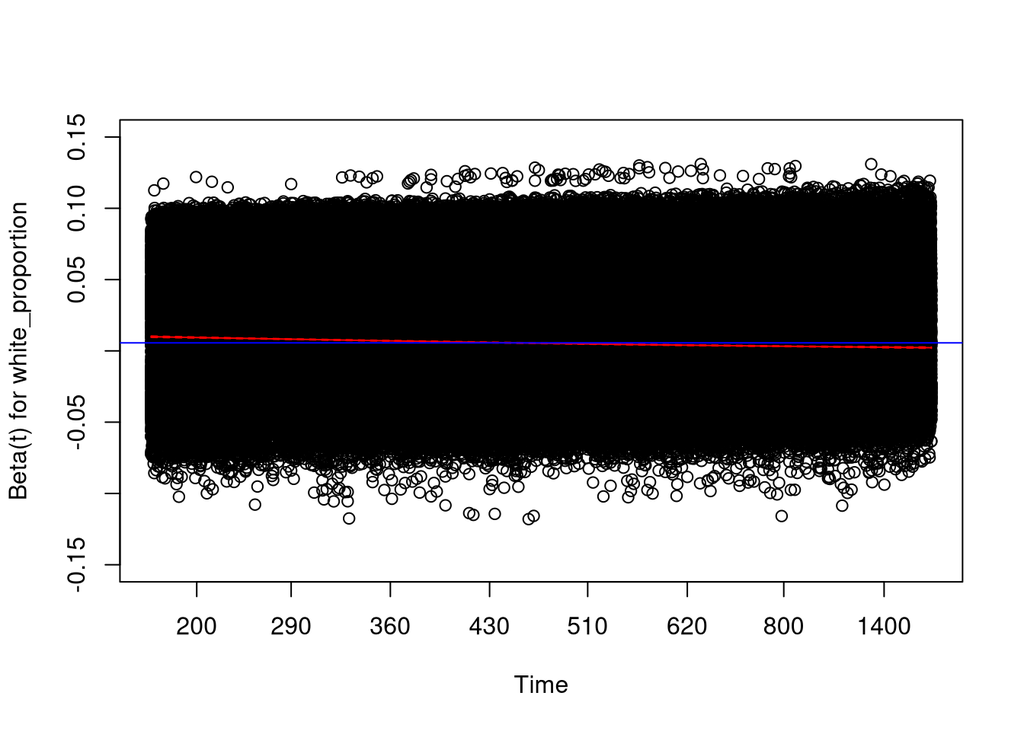

```r
plot(cox.zph(model3), var = 1, col = "red", ylim = c(-0.15, 0.15))
abline(h = coef(model3)[1], col = "blue")
```

Looks like it meets the PH assumption fairly well.

Now we can generate the KM estimates. To do so, we’ll generate an estimate for each percentage of white proportion by integer from 0% to 100%. For our other variables to adjust, we’ll use their respective modes and medians.

```r
mode <- function(x) {
  ux <- unique(x)
  return(ux[which.max(tabulate(match(x, ux)))])
}

white_data <- data.frame(white_proportion = seq(0, 100, 1), HELD_INDICATOR = mode(ems_traffic$HELD_INDICATOR), traffic = median(ems_traffic$traffic), INITIAL_SEVERITY_LEVEL_CODE = median(ems_traffic$INITIAL_SEVERITY_LEVEL_CODE), REOPEN_INDICATOR = mode(ems_traffic$REOPEN_INDICATOR), SPECIAL_EVENT_INDICATOR = mode(ems_traffic$SPECIAL_EVENT_INDICATOR), STANDBY_INDICATOR = mode(ems_traffic$STANDBY_INDICATOR), TRANSFER_INDICATOR = mode(ems_traffic$TRANSFER_INDICATOR))
```

```r
white_pred <- survfit(model3, newdata = white_data)
white_pred
```

```
## Call: survfit(formula = model3, newdata = white_data)
##
##         n events median 0.95LCL 0.95UCL
## 1   83554  83554    510     508     513
## 2   83554  83554    509     507     512
## 3   83554  83554    508     505     510
## 4   83554  83554    506     504     509
## 5   83554  83554    505     503     507
## 6   83554  83554    504     501     506
## 7   83554  83554    502     500     505
## 8   83554  83554    501     498     504
## 9   83554  83554    500     497     502
## 10  83554  83554    498     496     501
## 11  83554  83554    497     495     499
## 12  83554  83554    496     493     498
```

[output cut: 89 more lines]

Great, now we can assign that KM estimate to each zip code by rounding the white proportion of each observation and then joining with the KM estimates above, then grouping by zip code.

```r
survival_pred_lookup <- data.frame(white_proportion = seq(0, 100, 1), survival_pred = surv_median(white_pred)$median)
ems_traffic_pred <- ems_traffic %>%
  mutate(white_proportion = round(white * 100)) %>%
  inner_join(survival_pred_lookup, by = "white_proportion") %>%
  group_by(ZIPCODE, white_proportion) %>%
  summarize(mean_survival_pred = mean(survival_pred), median_survival = median(INCIDENT_RESPONSE_SECONDS_QY), median_traffic = median(traffic))
```

Now we can incorporate zip code geometry and write it to a shapefile for mapping.

```r
zips <- zctas() %>%
  mutate(ZCTA5CE10 = as.numeric(ZCTA5CE10)) %>%
  filter(ZCTA5CE10 %in% ems_traffic_pred$ZIPCODE) %>%
  select(ZCTA5CE10)

ems_traffic_pred <- merge(zips, ems_traffic_pred, by.x = "ZCTA5CE10", by.y = "ZIPCODE")
dir.create("../../data/processed/ems_traffic_pred/", showWarnings = F)
st_write(ems_traffic_pred, "../../data/processed/ems_traffic_pred/ems_traffic_pred.shp", append = F)
```

```
## Deleting layer `ems_traffic_pred' using driver `ESRI Shapefile'
## Writing layer `ems_traffic_pred' to data source
##   `../../data/processed/ems_traffic_pred/ems_traffic_pred.shp' using driver `ESRI Shapefile'
## Writing 167 features with 5 fields and geometry type Multi Polygon.
```